# Math Camp - Probability and Distributions Code Session

# Binomial Distribution

We can also see a perfect/abstract version of the distribution using the dbinom function to calculate the $PDF$.

Let’s look at the PDF of a binomial distribution where the probability of getting a success is 0.5 and we have one hundred trials.

This is equivalent to flipping one hundred coins. It shows us the probability of getting some number of heads in those hundred coin flips.

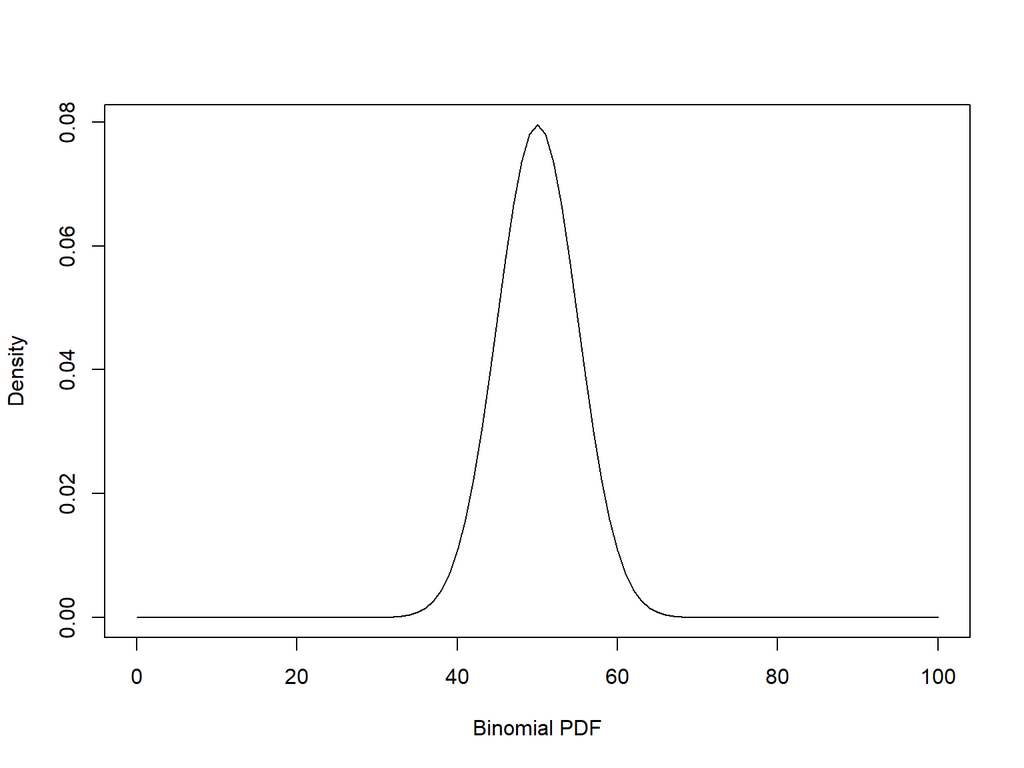

```r
binomPDF <- function(trials, prob)
{
  binomX <- seq(0,trials,1)

  plot(binomX, dbinom(x = binomX, size = trials, prob=prob),
     xlab="Binomial PDF", ylab="Density", type="l")
}
binomPDF(100,0.5)
```

This density plot is another way to look at these distributions. It is generally most useful for continuous distributions because they make it seem like there are value between integers when there are not.

# Binomial Distribubtion

**Play around with the binomPDF function, trying different numbers of trials and different probabilities of getting a success.**

```r
# work here
#binomPDF(trials=, prob=)
```

Notice that the binomial distribution often looks like a bell curve, but not always. The bell curve is the “normal” distribution. Sometimes a binomial distribution can be approximated by a normal distribution, but not always. A lot of the statistics used in social science assume a normal distribution.

# Binomial Distribution

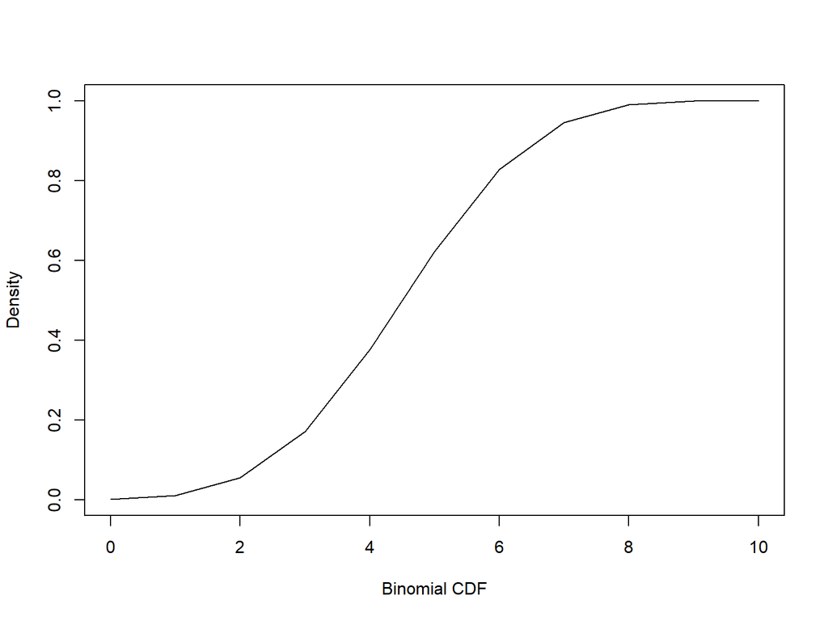

```r
binomCDF <- function(trials, prob)
{
  binomX <- seq(0,trials,1)

  plot(binomX, pbinom(q = binomX, size = trials, prob=prob),
     xlab="Binomial CDF", ylab="Density", type="l")
}
binomCDF(10,0.5)
```

# Binomial Distribution

Again, play around with the binomCDF and see how changing the number of trials and probability of success changes the CDF.

```r
# work here
#binomCDF()
```

# Bernoulli Distribution

The Bernoulli distribution is a special type of binomial distribution.

It is a one-event binomial distribution. Heads or tails. One coin.

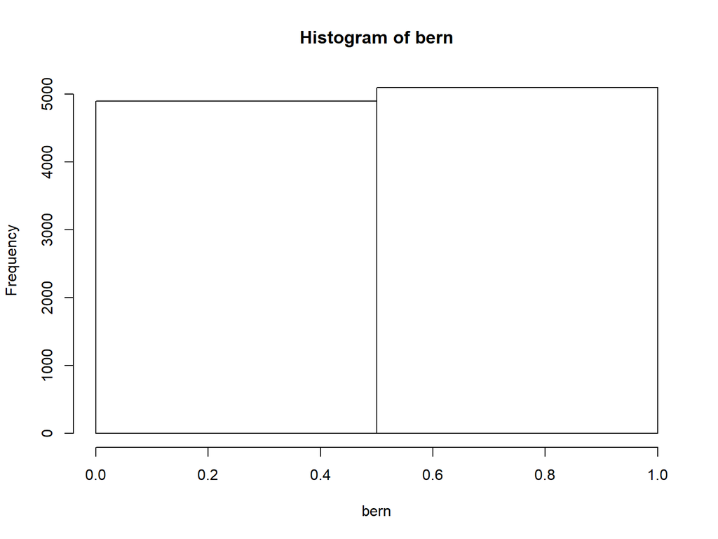

```r
bern <- rbinom(n=10000, size=1,prob=0.5)
hist(bern, breaks=2)
```

Yes/No events in the world that occur only one time per unit conform to this distribution. Events such as voting in a particular election.

# Bernoulli Distribution

We can access the $pdf$ and $cdf$ by using the “binom” functions and setting size = 1.

```r
# probability of getting 1 success/heads on one flip  -- probability mass function
dbinom(x = 1, size = 1, prob=0.5)
```

```
## [1] 0.5
```

```r
# probability of getting 1 or fewer successes -- cumulative probability distribution function
pbinom(q = 1, size=1, prob=0.5)
```

```
## [1] 1
```

**Guess why this moves from 0 to 1 above 0.50**

```r
qbinom(p=0.5, size=1, prob=0.5)
```

```
## [1] 0
```

```r
qbinom(p=0.5000000001, size=1, prob=0.5)
```

```
## [1] 1
```

# Binomial Distribution

Questions?

# Poisson Distribution

A Poisson distribution represents the number of times something happens in a fixed interval (often an amount of time).

- How many goals scored in a soccer/football match
- How many babies born in a year
- How many bacteria multiply in a minute

# Poisson Distribution

Let’s take draws from a Poisson distribution to simulate soccer goals.

We tell R the number of matches $n$ and the number of goals scored in an average game $lambda$.

```r
# 10 matches, on average 5 goals per match
rpois(n=10, lambda=5)
```

```
##  [1] 9 3 6 7 4 6 1 3 3 3
```

```r
# 10 matches, on average 0.5 goals per match
rpois(n=10, lambda=0.5)
```

```
##  [1] 0 0 0 1 1 2 0 0 1 1
```

# Poisson Distribution

**If the average number of goals per game is 0.5, but we play 10,000 matches, how many goals do you think will be scored in the highest scoring match?**

**If the average number of goals per game is 5, and we play 10,000 matches, how many goals do you think will be scored in the highest scoring match?**

# Poisson Distribution

**If the average number of goals per game is 0.5, and we play 10,000 matches, how many goals do you think will be scored in the highest scoring match?**

```r
#10000 matches, on average 0.5 goals per match
```

# Poisson Distribution

**If the average number of goals per game is 5, and we play 10,000 matches, how many goals do you think will be scored in the highest scoring match?**

```r
#10000 matches, on average 5 goals per match
(max(highPois <- rpois(n=10000, lambda=5)))
```

```
## [1] 17
```

# Poisson Distribution

Let’s take a look a Poisson distribution visually.

For a Poisson distribution, we need to tell R how many trials occur and the average number of events per trial.

This is equivalent to telling R how many soccer matches to simulate and how many goals to score in an average soccer match. The graph tells us the expected number of goals given a specific number of soccer matches.

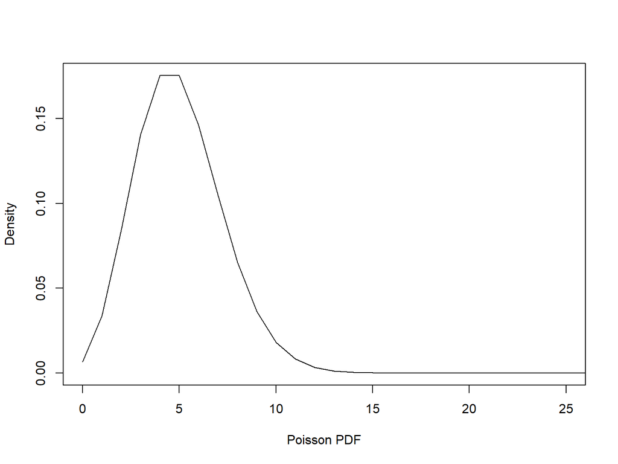

```
##       [,1]        [,2]
##  [1,]    0 0.006737947
##  [2,]    1 0.033689735
##  [3,]    2 0.084224337
##  [4,]    3 0.140373896
##  [5,]    4 0.175467370
##  [6,]    5 0.175467370
##  [7,]    6 0.146222808
##  [8,]    7 0.104444863
##  [9,]    8 0.065278039
## [10,]    9 0.036265577
```

```r
poisPDF <- function(trials, lamb)
{
  poisX <- seq(0,trials,1)

  plot(poisX, dpois(x = poisX, lambda=lamb),
     xlab="Poisson PDF", ylab="Density", type="l",
     xlim=c(0,max(5,lamb*5)))

  cbind(poisX[1:(min(10,length(poisX)))], dpois(x = poisX, lambda=lamb)[1:(min(10,length(poisX)))])
  # graph it and print out the first ten values and probabilities
}
poisPDF(100,5)
```

# Poisson Distribution

Now that we’ve seen the Poisson distribution, let’s look at some data drawn from it. We’ll start with a 5 lambda and 10,000 trials that we made above. We’ll use a histogram because density plots don’t always look good for discrete data.

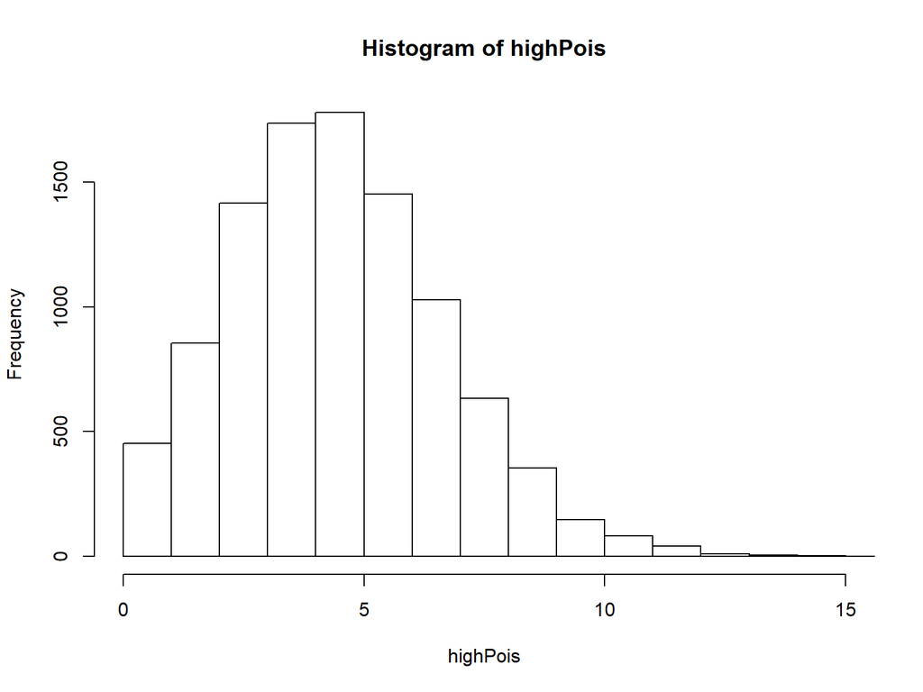

```r
hist(highPois, xlim=c(0,15))
```

```r
#plot(density(highPois)) # does not look good for discrete data.
```

Poisson distributions often have a particular right-skewed look because they cannot drop below 0 but have no theoretical maximum. The number of events that occurs in a given number of trials/amount of time cannot be negative, but it can be exceptionally large.

# Poisson Distribution

What does that 5 lambda distribution look like with only 30 observations?

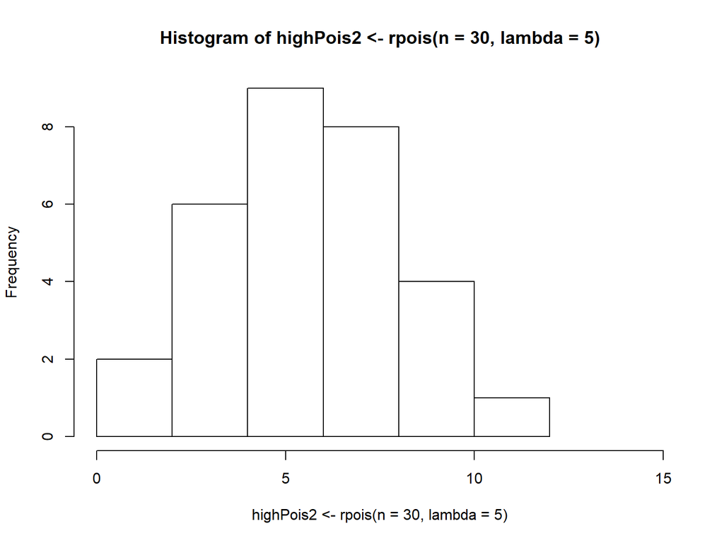

```r
hist(highPois2 <- rpois(n=30, lambda=5), xlim=c(0,15))
```

This comes from the same distribution as the above $highPois$ histogram. But that above has 10,000 observations. This only has thirty observations. Thirty is not really enough to look at this distribution and realize it is drawn from a Poisson with lambda 5.

# Poisson Distribution

Now let’s look at a Poisson distribution with a lambda of 3 and 10,000 draws.

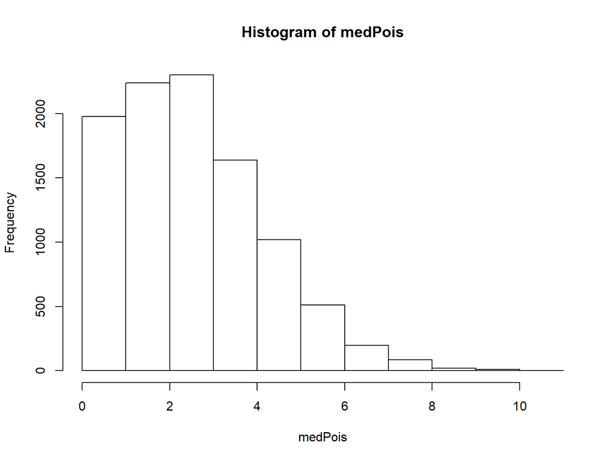

```r
medPois <- rpois(10000,3); thePois <- medPois
hist(medPois)
```

Notice that it is even more right-skewed than the lambda 5 distribution.

# Poisson Distribution

Now a Poisson with a lambda of only 0.5.

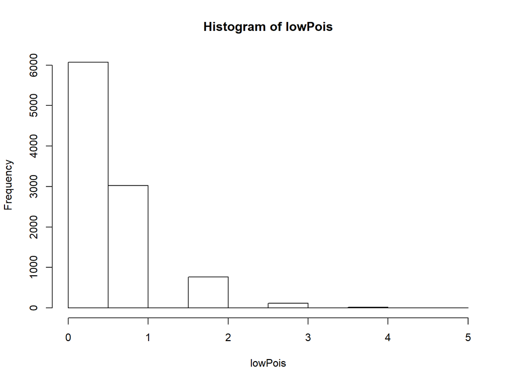

```r
lowPois <- rpois(n=10000, lambda=0.5)

hist(lowPois)
```

So right-skewed that it almost looks like an exponential distribution.

# Poisson Distribution

And here is an idealized version of that 0.5 lambda.

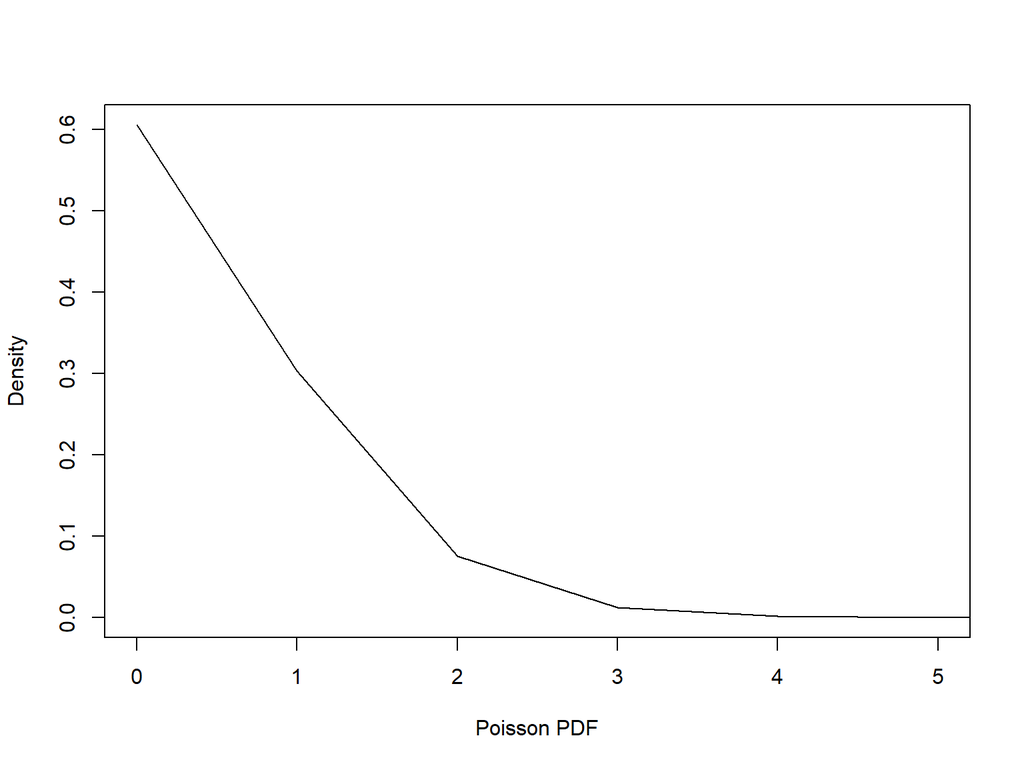

```
##       [,1]         [,2]
##  [1,]    0 6.065307e-01
##  [2,]    1 3.032653e-01
##  [3,]    2 7.581633e-02
##  [4,]    3 1.263606e-02
##  [5,]    4 1.579507e-03
##  [6,]    5 1.579507e-04
##  [7,]    6 1.316256e-05
##  [8,]    7 9.401827e-07
##  [9,]    8 5.876142e-08
## [10,]    9 3.264523e-09
```

```r
poisPDF(10000,0.5)
```

# Poisson Distribution

Now let’s look at a Poisson with a lambda of 60. For this, I think a density plot is more descriptive of the distribution.

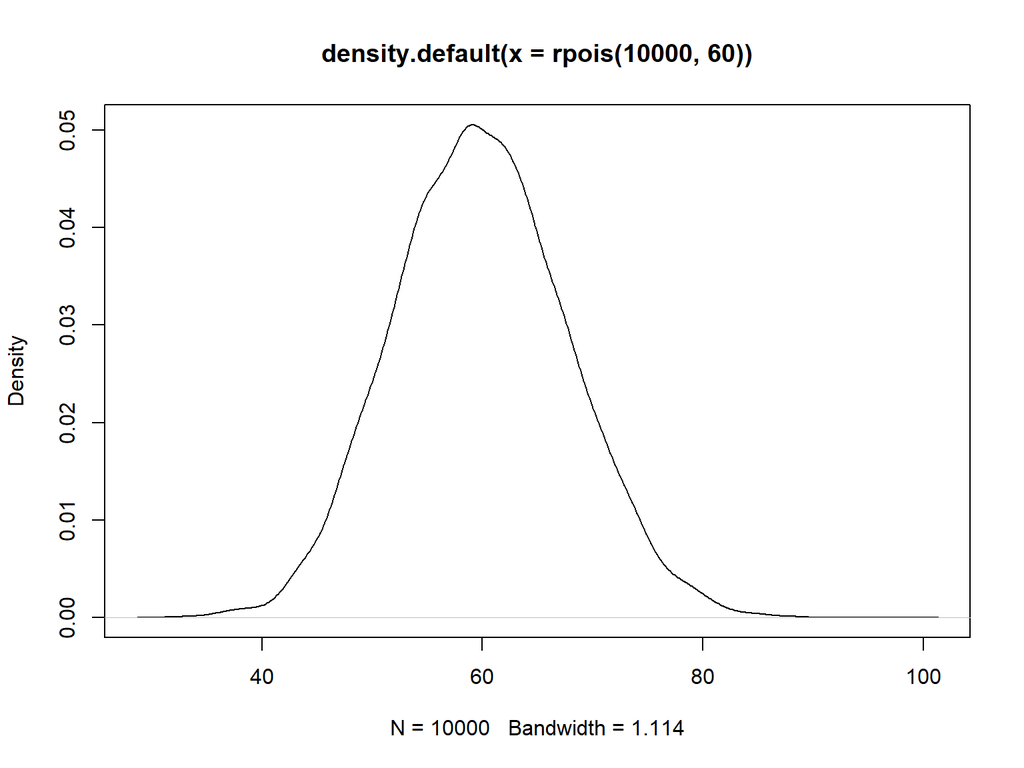

```r
plot(density(rpois(10000,60)))
```

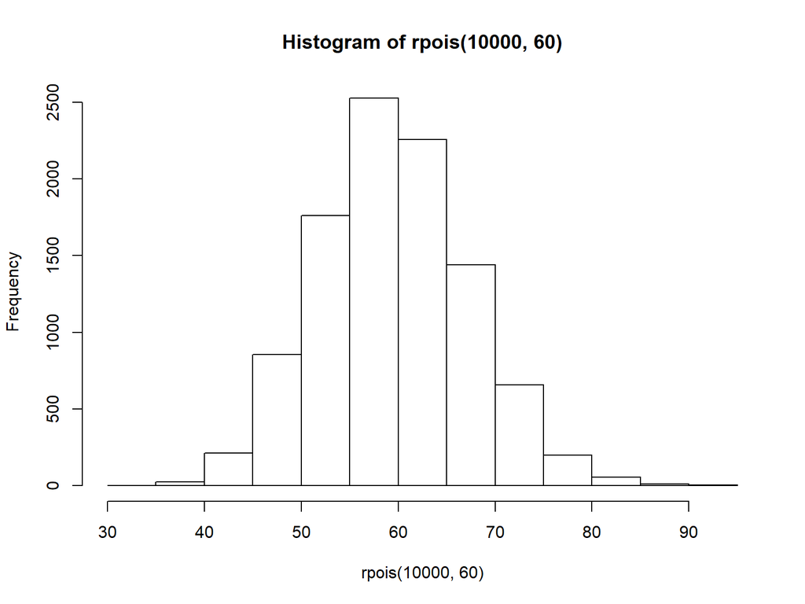

```r
hist(rpois(10000,60))
```

These distributions can vary greatly, depending on their characteristics. This one almost looks like a normal distribution, which we will cover in the section on continuous distributions.

# Poisson Distribution

**Using the dpois and ppois functions, tell me (1) the probability of getting exactly 5 goals in a match where 5 goals is lambda, and (2) the probability of getting at least 5 goals in a match where 5 goals is lambda.**

```r
#work here
```

# Discrete Distributions

Questions?

# Distributions - Continuous

We went through some of the most common discrete distributions: Discrete Uniform, Binomial, Bernoulli, Poisson.

Now let’s look at some of the most common continuous distributions. Remember, a continuous distribution is a distribution with an infinite number of outcomes.

Though most outcomes in the world are discrete, we often treat them as continuous to make our lives easier. GDP, Feelings Thermometers, etc do not really have an infinite number of outcomes, but they are close enough to approximate continuous distributions.

Two things we tend to care most about are represented by continuous distributions.

1. We tend to care about the “Average Treatment Effect” (ATE) of some phenomenon. The ATE should always be a continuous distribution.
2. We also care about the uncertainty around that ATE. The uncertainty, represented by standard errors or p-values, are also continuous distributions.

# Uniform Distribution

A continuous uniform distribution is a distribution with an infinite set of outcomes that occur with equal probability. Earlier we discussed the discrete uniform distribution with dice rolls.

P-values take a continuous uniform distribution. The amount of time you have to wait at the bus stop could also take the form of a continuous uniform distribution.

Let’s look at the probability density function for a uniform distribution.

# Uniform Distribution

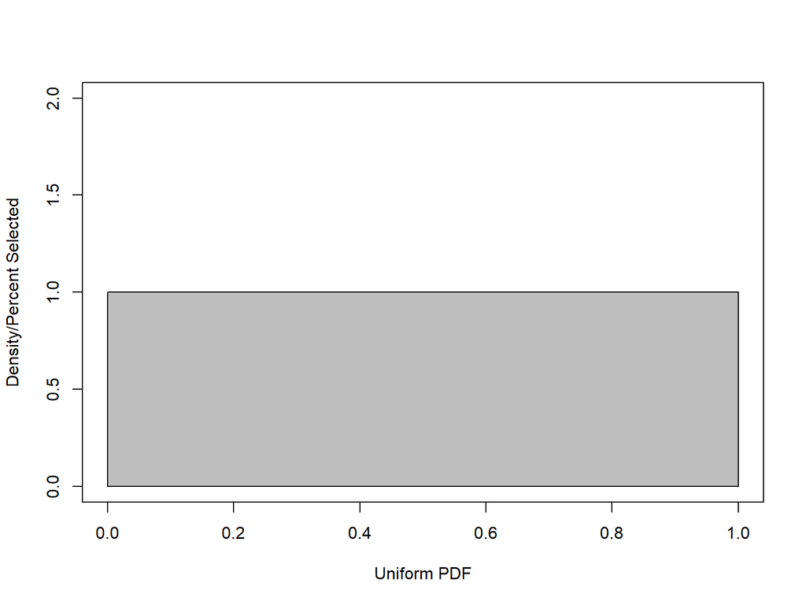

```r
unifPDF <- function(themin,themax)
  {
  unifX <- seq(themin,themax,.01)

  plot(unifX, dunif(x = unifX, min=themin,max=themax),
     xlab="Uniform PDF", ylab="Density/Percent Selected", type="l",
     xlim=c(themin,themax), ylim=c(0,(1/themax)*2))
  polygon(x=c(themin,themin,themax,themax), y=c(themin, 1/themax, 1/themax, themin),
          col="grey")

}
unifPDF(themin=0, themax=1)
```

Yep. Every number has an equal probability of being selected. Play around with that all you want and the shape will not change.

# Uniform Distribution

Now let’s take draws from a uniform distribution and look visually.

To take random draws from a uniform distribution, we need to tell R how many draws we want to make, the minimum possible value, and the maximum possible value.

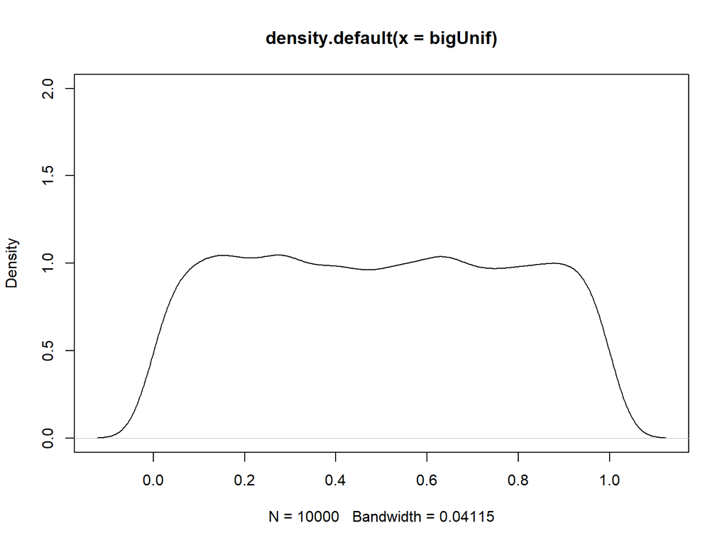

```r
bigUnif <- runif(n=10000,min=0,max=1); theUnif <- bigUnif
plot(density(bigUnif), ylim=c(0,2))
```

Due to randomness, even with lots of draws, draws from a uniform distribution will not yield an exactly straight line. But it’s pretty close.

# Uniform Distribution

**Using the punif function for a uniform distribution from 0 to 1, tell me how often we should draw a number 0.5 or smaller.**

```r
#work here
```

# Uniform Distribution

In our actual uniform distribution, how often do we draw a number 0.5 or smaller?

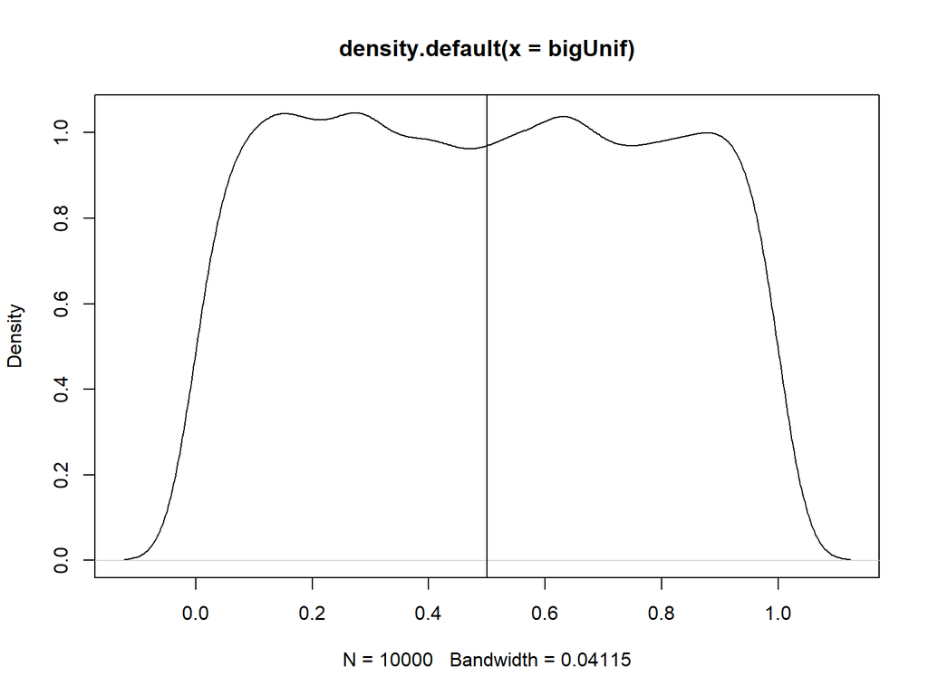

```r
plot(density(bigUnif))
abline(v=0.5)
```

```r
mean(bigUnif<=0.5)
```

```
## [1] 0.5016
```

Observed distributions differ slightly from their perfect/abstract distributions because of randomness.

# Uniform Distribution

**How often will we draw a number 0.5 or less on only 10 draws from a uniform distribution?**

```r
#work here
```

# Uniform Distribution

Most of yours probably did not look very uniform.

Remember, the fewer draws from the distribution, the less the data look like the distribution. Sampling from a distribution only starts to resemble the actual distribution after a high number of draws, 30+.

# Uniform Distribution

Questions?

# Normal Distribution

As the name implies, the normal distribution represents most physical and social phenomena. This is also called the Gaussian Distribution.

Most ATEs are normal/Gaussian. Many physical phenomenon form a normal distribution: height, weight, brain size, petal size of a flower, red/white blood cell counts, lots of things.

Let’s look at a normal distribution visually.

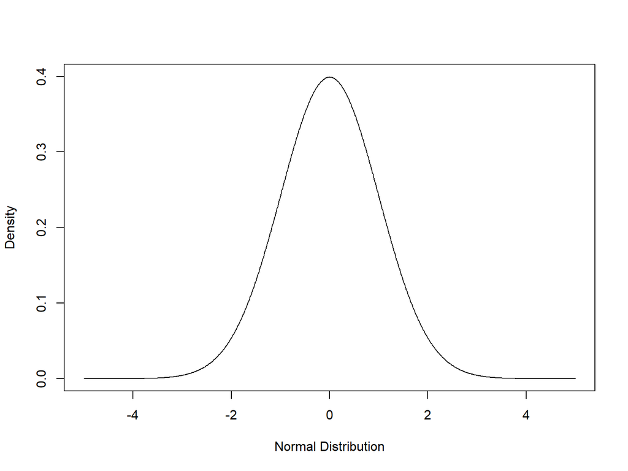

```r
norm.fun <- function(themean, thesd)
{
  normX <- seq(-5,5,.01)
  plot(normX,dnorm(normX, mean=themean, sd=thesd), xlab="Normal Distribution", ylab="Density", type="l", xlim=c(-5,5), ylim=c(0,0.4))

}
norm.fun(0,1)
```

Play around with that to see how the normal distribution changes.

# Standard Normal Distribution

There is a special type of normal distribution we tend to work with: the standard normal. This is a normal distribution with mean = 0 and sd = 1.

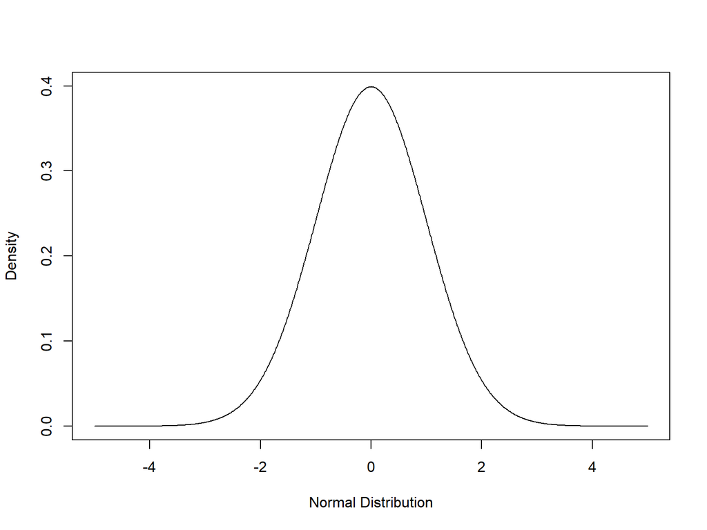

```r
norm.fun(0,1)
```

# Normal Distribution

**Practice taking draws from a normal distribution. Take 10,000 draws from a normal distribution with mean 0 and sd 1, then plot it.**

```r
# use ?rnorm if you need help
```

# Normal Distribution

As with the other distributions, R has built in functions to tell us about an idealized normal distribution.

$dnorm$ tells us what percentage of the distribution is at a certain point (technically, an interval around that point because you cannot calculate one point out of an infinite number of points).

```r
dnorm(0, mean=0, sd=1)
```

```
## [1] 0.3989423
```

# Normal Distribution

$pnorm$ tells us what percentage of the distribution is at or below a certain point.

```r
pnorm(0, mean=0, sd=1)
```

```
## [1] 0.5
```

# Distributions

Questions?

# Descriptive Statistics

Descriptive statistics are characteristics of distributions.

These are often what we care about in quantitative social science.

# Expected Value/Mean

The average value.

```r
x <- c(0:100, seq(100,200,10))
mean(x)
```

```
## [1] 59.82143
```

# Median and Mode

The middle value and the value that appears most often.

```r
median(x)
```

```
## [1] 55.5
```

There is not actually an easy way to calculate mode in R!

```r
tail(sort(table(x)))
```

```
## x
## 160 170 180 190 200 100
##   1   1   1   1   1   2
```

# Quantiles

The value at different parts of the distribution.

```r
quantile(x, c(0.25, 0.50, 0.75))
```

```
##   25%   50%   75%
## 27.75 55.50 83.25
```

# Summary

The summary function gives lots of nice information.

```r
summary(x)
```

```
##    Min. 1st Qu.  Median    Mean 3rd Qu.    Max.
##    0.00   27.75   55.50   59.82   83.25  200.00
```

# Range and Sum

The min and max values.

```r
range(x)
```

```
## [1]   0 200
```

The sum of all the values.

```r
sum(x)
```

```
## [1] 6700
```

# Inter-Quartile Range, Standard Deviation, and Variance

These are all measures of dispersion.

**Inter-Quartile Range** is the size of the middle 50% of the distribution. How big is the area between 25th and 75th percentile?

```r
IQR(x)
```

```
## [1] 55.5
```

**Standard deviation** is the distribution’s average distance from the mean. Low values indicate the data are all clustered near the mean, high values mean the data are very far from the mean.

```r
sd(x)
```

```
## [1] 42.02599
```

**Variance** is standard deviation squared.

```r
var(x)
```

```
## [1] 1766.184
```

```r
sd(x)^2
```

```
## [1] 1766.184
```

# Correlation and Covariance

Correlation is the relationship between two variables. The *correlation coefficient* represents how much of the variance in one variable is due to another variable.

It ranges from -1 to +1. At 0 the variables are unrelated. At high values one variable increases as the other increases. At low values one variable decreases as the other increases. At 1 or -1 one variable completely determines the other.

```r
y <- x+rnorm(length(x)) # basically still x
y2 <- x+100*rnorm(length(x)) # fairly different from x
z <- rnorm(length(x)) # no relationship to x
cor(x,y)
```

```
## [1] 0.9997785
```

```r
cor(x,y2)
```

```
## [1] 0.1584174
```

```r
cor(x,z)
```

```
## [1] -0.1262016
```

# Correlation and Covariance

Covariance is like an unstandardized correlation. It is larger when two variables are more correlated, but the overall variance of the outcomes also makes the covariance larger.

In this example, we know $x$ & $y$ are the most similar, but the covariance of $x$ and $y2$ is high despite lower correlation because $y2$ has a very high internal variance.

```r
cov(x,y)
```

```
## [1] 1766.379
```

```r
cov(x,y2)
```

```
## [1] 739.3882
```

```r
cov(x,z)
```

```
## [1] -5.368656
```

# Correlation and Covariance

We can divide the covariance by the joint standard deviation to get the correlation.

```r
cov(x,y)/(sd(x)*sd(y))
```

```
## [1] 0.9997785
```

```r
cor(x,y)
```

```
## [1] 0.9997785
```

```r
cov(x,y2)/(sd(x)*sd(y2))
```

```
## [1] 0.1584174
```

```r
cor(x,y2)
```

```
## [1] 0.1584174
```